# The Weibull Distribution

Gary Mitchell

August 25, 2026

The Weibull distribution can be thought of as a *family* of related distributions. As we shall see, the *exponential* distribution is just a special case of the Weibull distribution.

The Weibull distribution is a flexible, non-negative (i.e., bounded below), continuous distribution. It has many potential applications in business, especially those involving time between events and time to failure.

The Weibull distribution is a real-valued distribution with two parameters. The standard parameterization of the Weibull distribution utilizes $\lambda$ as a scale parameter. Unfortunately, this differs from the role of $\lambda$ in the Poisson and exponential distributions. To (hopefully) reduce confusion around these distributions, we will define the Weibull distribution using the following parameterization:

- Rate parameter $\lambda = \frac{1}{\beta}$
- Shape parameter $k$

where $\beta$ represents the scale parameter in the standard Weibull parameterization.

To communicate that we have a random variable $X$ that follows a Weibull distribution with shape $k$, and rate $\lambda$, we say

$$X \sim Weibull(k, \lambda)$$

### Understanding *Shape*

Understanding the *shape* parameter, $k$, is a little easier than understanding the Weibull distribution’s shape parameters. Still, to gain some *intuition* about the Weibull distribution, you can (loosely) think of $k$ as determining how the failure rate changes over time.

To further our understanding of the Weibull distribution, we can observe the following *rules of thumb*:

- $k < 1$
  - Items fail fast initially
  - Failure risk drops for items that survive (i.e., do not fail early)
- $k = 1$
  - Special case where the Weibull distribution simplifies to an exponential distribution
- $1 < k < 3.5$
  - The risk of failure grows as time passes (e.g., item wears out)
  - Useful for modeling fatigue and mechanical degradation over time
- $k \approx 3.5$ or higher
  - Approaches a symmetrical shape similar to a normal distribution
  - Useful for modleing highly predictable failure: items rarely fail early, performing reliably for a lengthy period, then the entire population begins to fail with very high probability at the same time.

### Some Sample Weibull Distributions

The best way I know to gain familiarity with the Weibull distribution is to look at the density function for various combinations of $\alpha$ and $\beta$. Let’s start by looking at different values of $k$ with $\lambda = 1$:

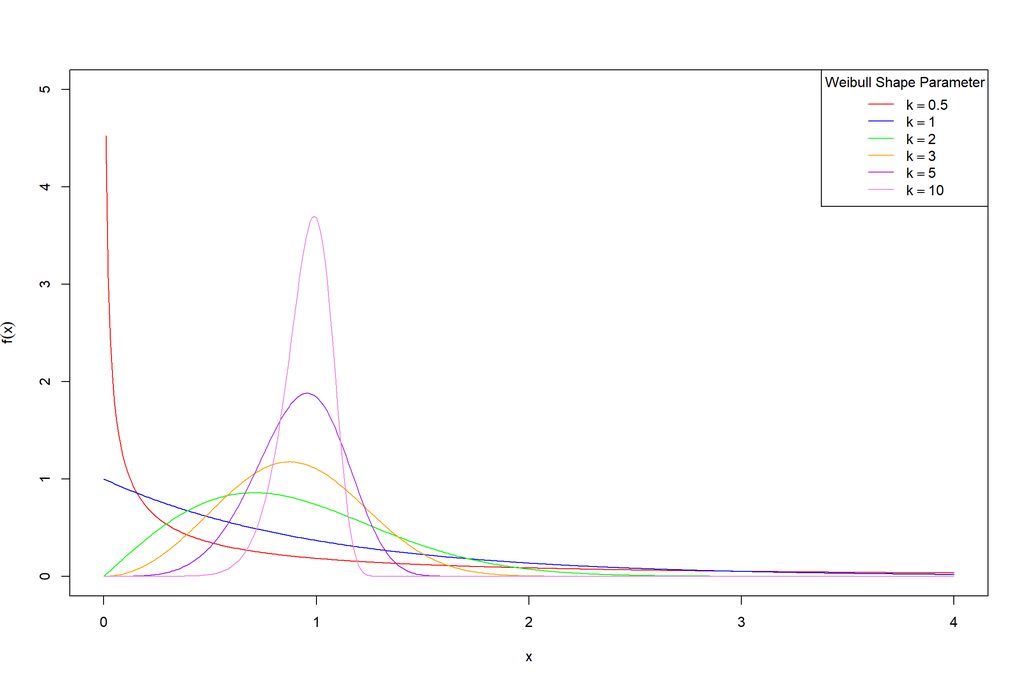

### Weibull Distribution Known Properties

For *any* standard Weibull distribution:

$$\mu_x = E[x] =
\frac{1}{\lambda}\Gamma\biggl(1+\frac{1}{k}\biggr)$$
where the Gamma function, $\Gamma(n)=\int_0^\infty t^{n-1}e^{-t}dt$ extends the factorial function to continuous numbers. The variance of the standard Weibull distribution is given by:

$$\sigma_x^2 = V[x] =
\Biggr[\Gamma\biggl(1+\frac{2}{k}\biggr)-\biggl(\Gamma\left(1+\frac{1}{k}\right)\biggr)^2\Biggr]$$

And as always,
$$\sigma_x =
\sqrt{\sigma_x^2}$$

### Standard Weibull Probability Density Function

As with all continuous distributions, the standard Weibull’s *probability density* function *does not represent a point probability*; recall that $Pr\{X = x\} \equiv 0$. The Weibull distributions’s probability densitty function is:

$$f(x) =
\begin{cases}
\lambda k(\lambda x)^{k-1}e^{-(\lambda x)^k},&x \geq 0 \\
0&x < 0
\end{cases}$$
Note: for the special case where $k=1$, the PDF simplifies to

$$f(x) =
\begin{cases}
\lambda e^{-\lambda x},&x \geq 0 \\
0&x < 0
\end{cases}$$
In other words, the Weibull distribution with $k=1$ simplifies to an exponential distribution.

Remember, this form of the PDF is written such that the use of $\lambda$ is consistent witht the exponential distribution, i.e., $\lambda$ is the *rate* of the distribution. An alternative formulation of the Weibull distribution uses $\alpha = \frac{1}{\lambda}$:

$$f(x) =
\begin{cases}
\frac{k}{\alpha}(\frac{x}{\alpha})^{k-1}e^{-(\frac{x}{\alpha})^k},&x
\geq 0, \alpha > 0 \\
0&x < 0
\end{cases}$$
In this formulation, $\alpha$ can be interpreted as the average time between failures (or arrivals). I’ve presented this form so that you won’t be thrown off if you see the Weibull distribution stated this way in reference material you may come across. However, for this class, we will utilize the first formulation stated in terms of $\lambda$.

### Cumulative Probability Function

As with *all* continuous probability distributions, the Weibull distribution’s cumulative probability is calculated by integrating the density function between the lower bound and $x$:

$$Pr\{X \leq x\} = F(x) =
\begin{cases}
1-e^{-(\lambda x)^k}, & x\geq 0\\
0, & x<0
\end{cases}$$

### Inverse Cumulative Probability

Conceptually, the inverse cumulative probability function for a Weibull distribution is:

$$F^{-1}(p) = x:F(x) \geq p =
\frac{(-ln(1-p))^\frac{1}{k}}{\lambda}$$

### Mode

The mode for the standard Weibull distribution can be expressed completely in terms of $\lambda$ and $k$:

where $\mathbf{M_o}(X)$ is a common convention to denote the mode of $X$.

### The General Weibull Distribution

The general Weibull distribution is a *shifted* distribution. While we can certainly redefine the density function and all of the summary metrics, it is easiest to just define the general Weibull distribution in terms of the shift:

$$f_a(x)=f(x-a)$$
$$F_a(x)=F(x-a)$$

$$F_a^{-1}(p) = a + F^{-1}(p)$$
$$\mu_{x_a}=E_a[x] = a + E[x]=a
+\mu_x$$

where we use the *sub-subscript* $a$ as a notational convention indicating the *the shifted distribution for* $x$, e.g., $\mu_{x_a}$ is the mean of the shifted distribution for $x$.

Because there is no variation in the shift,

$$\sigma_{x_a}^2 = \sigma_x^2$$

$$\mathbf{M_{o_a}(x)} = a +
\mathbf{M_o(X)}$$

and finally

$$\mathbf{M_{d_a}(X)} = a +
\mathbf{M_d(X)}$$

## The Weibull Distribution in Use

Although the expressions for $f(x)$, $F(x)$, and $F^{-1}(p)$ are manageable in Excel, R, and Python, It’s nice that we don’t have to (at least for $f(x)$ and $F(x)$; Excel does not provide an inverse cumulative Weibull probability function.

| To.Calculate | Excel | R | Python |
| --- | --- | --- | --- |
| $f(x)$ | WEIBULL.DIST($x, k, \alpha, 0$) | $dweibull(x, k, \alpha)$ | $weibull\_min.pdf(x, k, a, \alpha)$ |
| $F(x) = Pr\{X \leq x\}$ | WEIBULL.DIST($x, k, \alpha, 1$) | $pweibull(x, k, \alpha)$ | $weibull\_min.cdf(x, k, a, \alpha)$ |
| $F^{-1}(prob)$ | $(-ln(1-p))\text{^}(1/k) / \lambda$ | $qweibull(p, k, \alpha)$ | $weibull\_min.ppf(p, k, a, \alpha)$ |

where $\alpha = \frac{1}{\lambda}$, and $a$ is the shift.

The sections below highlight the nuances involved in calculating Weibull probabilities in Excel, R, and SciPy (Python) all have their nuances (i.e., explain the calculations in the table above).

### Weibull distribution functions in Excel

Excel’s Weibull distribution function accepts only the shape and scale parameters (i.e., it does not accept the shift for a general Weibull distribution). However, Excel provides a single function, WEIBULL.DIST, to calculate both PDF and CDF. WEIBULL.DIST’s *fourth* parameter indicates whether to calculate the PDF (0) or the CDF (1) for the Weibull distribution.

### Weibull distribution functions in R

R provides functions only for a *standard* Weibull distribution (i.e., like Excel, it does not directly support the shift for a General Weibull Distribution).

The following code illustrates using R to calculate various probabilities for a random variable $X \sim Weibull(2, 1/3)$.

```r
k<-2
lambda<-1/3
alpha <- 1/lambda

x<-5

prob <- 0.82

fx <- round(dweibull( x, k, alpha), 4)
Fx <- round(pweibull( x, k, alpha), 4)
invFx <-round(qweibull(prob, k, alpha), 2)
```

The results are:

- $f(5) = 0.0691$
- $F(5) = 0.9378$
- $F^{-1}(0.82) = 3.93$

And, to further illustrate the relationship between the exponential and Weibull distributions (as well as transforming for the call to R’s functions), look closely at the following code and resulting graphs.

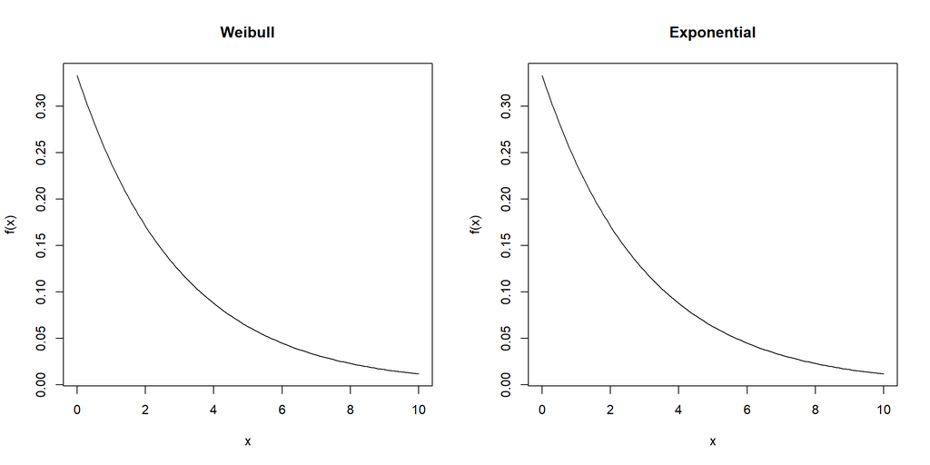

```r
x<-seq(0,10,0.1)

par(mfrow=c(1,2))
k<-1
lambda<-1/3

# PLot the weibull first
plot(x, dweibull(x, k, 1/lambda), type='l', main='Weibull', ylab='f(x)')

# Plot the exponential
plot(x, dexp(x, lambda), type='l', main='Exponential', ylab='f(x)')
```

```r
par(mfrow=c(1,1))
```

### Weibull Distribution functions in Python (SciPy)

SciPy allows us to use its distribution functions in two ways:

- Directly, passing *all* distribution parameters
- Using frozen distributions (which *remember* the distribution’s parameters).

Either way, to access SciPy’s Weibull distribution, we must first import **scipy.stats.weibull_min**.

The following code two examples illustrate using SciPy to calculate various probabilities for a random variable $X \sim weibull(2, 1/3)$ (the same as in the R example above).

#### Using SciPy Probability Functions

SciPy uses a different (and potentially confusing convention) for its Weibull distribution parameters. These are:

- $c$ - what is conventionally referred to as $k$
- $loc$ - the lower bound of the distribution (i.e., the conventional $a$)
- $scale$ - what is conventionally referred to as $\frac{1}{\lambda}$.

```python
from scipy.stats import weibull_min

k = 2

# lambda is intentionally misspelled below to avoid conflict with Python's
# reserved work lambda for creating lambda expressions
lamda = 1/3

x = 5
prob = 0.82

# We have to pass all distribution parmeters in every call
fx = round(weibull_min.pdf(x, k, scale=1/lamda), 4)
Fx = round(weibull_min.cdf(x, k, scale=1/lamda),4)
invFx = round(weibull_min.ppf(prob, k, scale=1/lamda), 2)
```

The results are:

- $f(x) = 0.0691$
- $F(x) = 0.9378$
- $F^{-1}(x) = 3.93$

#### Using SciPy Frozen Distribution

This example instantiates and uses a weibull_min frozen distribution object to calculate the probabilities. When instantiating a frozen Weibull distribution, we simply pass the expected arguments (see previous example) to the constructor.

```python
from scipy.stats import weibull_min

k = 2
lamda = 1/3

x = 5
prob = 0.82

# We pass the distribution parameters when instantiating the Weibull distribution object
dist = weibull_min(k, scale=1/lamda)

# Because dist knows its parameters, we omit them from the method calls
fx_frozen = round(dist.pdf(x), 4)
Fx_frozen = round(dist.cdf(x),4)
invFx_frozen = round(dist.ppf(prob), 2)
```

The results are:

- $f(x) = 0.0691$
- $F(x) = 0.9378$
- $F^{-1}(x) = 3.93$

Personally, I much prefer using SciPy frozen distributions and almost always do so. The code is cleaner, and it’s much easier to pass a single frozen distribution object to a function call, then it is to pass all of the distributions parameters.

## Example Application

Assume your company manufactures a product whose wear-out failures increase as a function of time, and wants to know the probability a unit fails within 12 months (with average time to failure of 36 months). Additionally, the company wants to know the expected one-year liability (i.e., the expected warranty cost) for the units shipped to date.

Assuming the time to failure follows a Weibull distribution with $k = 2$ to reflect the increasing failure rate, and given the average time to a failure of 36 months (i.e., $\lambda = 1/36$), then we model time to failure as:

$$T \sim Weibull(2, 1/36)$$

To answer the company’s first question, we calculate $Pr\{T <= 12\}$ using the Weibull cumulative distribution function

```python
k = 2
lamda = 1/36
t = 12

Ft = round(weibull_min.cdf(t, k, scale=1/lamda), 4)
```

So, the probability that a unit will fail within 12 months is:

$$F(12) = 0.1052$$

In other words, we can expect 10.52% of the units to fail within the first 12 months.

Now assume that each warranty claim has an *expected cost* of $\$50$ and we have shipped $10,000$ during the first month of production. We can now calculate the *expected warranty liability* as follows:

$$\begin{align}
E[liability] & = units\ shipped \times cost\ per\ unit \times
Pr\{T \leq 12\} \\
& = 10,0000 \times \$ 50 \times 0.1052 \\
& = \$52,600
\end{align}$$